# Hearbeat Acoustic Analysis

This analysis is performed over heart beat sound wave files, available for public in Kaggle: [Source](https://www.kaggle.com/datasets/kinguistics/heartbeat-sounds). The dataset consists of two sources: (A) from general public via iStethoscope Pro iPhone and (B) from clinic trial in hospitals, using digital stethoscope DigiScope.

This problem consists of a classification problem, over time-series data, for detection of healthy hearts and abnormal ones.  
The study case presented here works on feature engineering over time-series data, as well as spectral engineering and ROC curve.

```python
import numpy as np
import pandas as pd
import matplotlib.pyplot as plt
from glob import glob
from statistics import median
import re

import librosa as lr
from librosa.core import stft, amplitude_to_db
from librosa.display import specshow

from sklearn.linear_model import LogisticRegression
from sklearn.metrics import roc_curve, roc_auc_score, accuracy_score, recall_score
from sklearn.calibration import CalibratedClassifierCV
```

```python
a_df = pd.read_csv('archive/set_a.csv')
a_df = a_df[['fname', 'label']]
a_df['fname'] = 'archive/'+a_df['fname']
a_df
```

|  | fname | label |
| --- | --- | --- |
| 0 | archive/set_a/artifact__201012172012.wav | artifact |
| 1 | archive/set_a/artifact__201105040918.wav | artifact |
| 2 | archive/set_a/artifact__201105041959.wav | artifact |
| 3 | archive/set_a/artifact__201105051017.wav | artifact |
| 4 | archive/set_a/artifact__201105060108.wav | artifact |
| ... | ... | ... |
| 171 | archive/set_a/__201108222241.wav | NaN |
| 172 | archive/set_a/__201108222244.wav | NaN |
| 173 | archive/set_a/__201108222247.wav | NaN |
| 174 | archive/set_a/__201108222254.wav | NaN |
| 175 | archive/set_a/__201108222257.wav | NaN |

176 rows × 2 columns

```python
a_df['label'].value_counts(dropna=False)
```

```
NaN         52
artifact    40
murmur      34
normal      31
extrahls    19
Name: label, dtype: int64
```

```python
b_df = pd.read_csv('archive/set_b.csv')
b_df
```

|  | dataset | fname | label | sublabel |
| --- | --- | --- | --- | --- |
| 0 | b | set_b/Btraining_extrastole_127_1306764300147_C... | extrastole | NaN |
| 1 | b | set_b/Btraining_extrastole_128_1306344005749_A... | extrastole | NaN |
| 2 | b | set_b/Btraining_extrastole_130_1306347376079_D... | extrastole | NaN |
| 3 | b | set_b/Btraining_extrastole_134_1306428161797_C... | extrastole | NaN |
| 4 | b | set_b/Btraining_extrastole_138_1306762146980_B... | extrastole | NaN |
| ... | ... | ... | ... | ... |
| 651 | b | set_b/Btraining_normal_Btraining_noisynormal_2... | normal | noisynormal |
| 652 | b | set_b/Btraining_normal_Btraining_noisynormal_2... | normal | noisynormal |
| 653 | b | set_b/Btraining_normal_Btraining_noisynormal_2... | normal | noisynormal |
| 654 | b | set_b/Btraining_normal_Btraining_noisynormal_2... | normal | noisynormal |
| 655 | b | set_b/Btraining_normal_Btraining_noisynormal_2... | normal | noisynormal |

656 rows × 4 columns

```python
b_df['label'].value_counts(dropna=False)
```

```
normal        320
NaN           195
murmur         95
extrastole     46
Name: label, dtype: int64
```

Database (A) contains 176 audio files and database (B) contains 656 audio files. These records are labeled in four classes:

- Normal: indicates a healthy heart beat
- Artifact (only A): indicates unregular, too noisy, or not heartbeat waveforms
- Murmur: one of abnormalities in heart beat
- Extrahls (A) or Extrastole (B): one of abnormalities in heart beat

Some of the data does not have a label, indicating NaN.

# Individual analysis

We will start with individual analysis, over one waveform from each class, from database A, to illustrate the feature engineering process, before moving on to the classification model.

```python
files = ['archive/set_a/normal__201103170121.wav',
         'archive/set_a/artifact__201106050353.wav',
         'archive/set_a/extrahls__201101241423.wav',
         'archive/set_a/murmur__201101180902.wav'
         ]
```

```python
audios = []
times = []

# Reading auditory data
for file in files:
    audio, sfreq = lr.load(file)
    audios.append(audio)

    # Creating time array
    indices = np.arange(0, len(audio))
    times.append(indices/sfreq)
```

```python
sfreq # sampling frequency (same for every file, prior checked)
```

```
22050
```

```python
df = pd.DataFrame({
    'normal': audios[0][:176400],
    'artifact': audios[1][:176400],
    'extrahls': audios[2][:176400],
    'murmur': audios[3][:176400]
}, index = times[0][:176400])
df
```

|  | normal | artifact | extrahls | murmur |
| --- | --- | --- | --- | --- |
| 0.000000 | -0.002086 | 0.001620 | -0.003448 | -0.043658 |
| 0.000045 | -0.002933 | 0.002505 | -0.004786 | -0.063429 |
| 0.000091 | -0.002454 | 0.002712 | -0.003911 | -0.055169 |
| 0.000136 | -0.003028 | 0.003359 | -0.003882 | -0.059671 |
| 0.000181 | -0.002875 | 0.003370 | -0.003303 | -0.055605 |
| ... | ... | ... | ... | ... |
| 7.999773 | 0.000226 | -0.005503 | 0.000161 | -0.040152 |
| 7.999819 | 0.000171 | -0.004669 | -0.000015 | -0.039910 |
| 7.999864 | 0.000138 | -0.003795 | 0.000310 | -0.039516 |
| 7.999909 | 0.000653 | -0.003394 | 0.000330 | -0.039116 |
| 7.999955 | 0.001223 | -0.002117 | 0.000449 | -0.038825 |

176400 rows × 4 columns

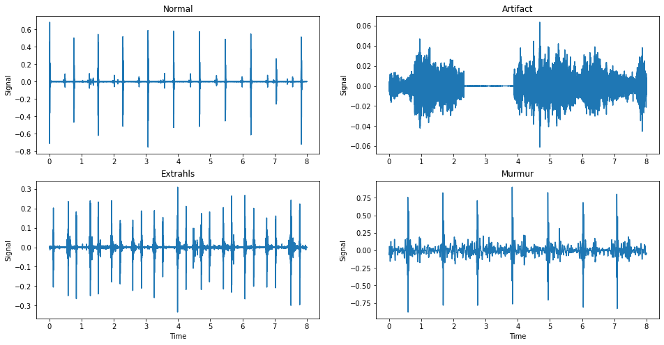

```python
# Ploting waveform
fig, ax = plt.subplots(2, 2, figsize=(16,8))
ax[0,0].plot(df.index, df['normal'])
ax[0,0].set_ylabel('Signal')
ax[0,0].title.set_text('Normal')
ax[0,1].plot(df.index, df['artifact'])
ax[0,1].set_ylabel('Signal')
ax[0,1].title.set_text('Artifact')
ax[1,0].plot(df.index, df['extrahls'])
ax[1,0].set_xlabel('Time')
ax[1,0].set_ylabel('Signal')
ax[1,0].title.set_text('Extrahls')
ax[1,1].plot(df.index, df['murmur'])
ax[1,1].set_xlabel('Time')
ax[1,1].set_ylabel('Signal')
ax[1,1].title.set_text('Murmur')
plt.show()
```

As noted before, the Extrahls and Murmur indicate two types of abnormalities in heart beats. Artifact files have too much background noise or inaudible heart beats.

## Envelope features

Since we are dealing with sound waves, which is a particular kind of time series data, we may work on envelope. It consists of smoothing and averaging over rolling window.

```python
# Feature engineering of the data: smoothing and envelope
window_size = 500
audio_rectified = df.apply(np.abs)
audio_envelope = audio_rectified.rolling(window_size).mean()
```

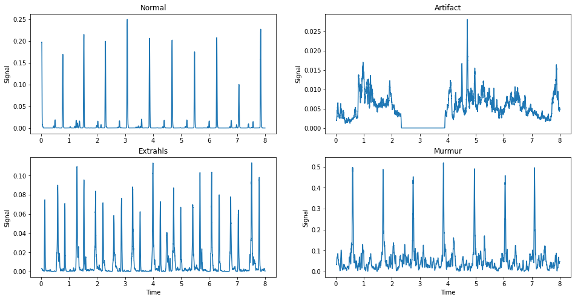

```python
# Ploting waveform
fig, ax = plt.subplots(2, 2, figsize=(16,8))
ax[0,0].plot(audio_envelope.index, audio_envelope['normal'])
ax[0,0].set_ylabel('Signal')
ax[0,0].title.set_text('Normal')
ax[0,1].plot(audio_envelope.index, audio_envelope['artifact'])
ax[0,1].set_ylabel('Signal')
ax[0,1].title.set_text('Artifact')
ax[1,0].plot(audio_envelope.index, audio_envelope['extrahls'])
ax[1,0].set_ylabel('Signal')
ax[1,0].set_xlabel('Time')
ax[1,0].title.set_text('Extrahls')
ax[1,1].plot(audio_envelope.index, audio_envelope['murmur'])
ax[1,1].set_ylabel('Signal')
ax[1,1].set_xlabel('Time')
ax[1,1].title.set_text('Murmur')
plt.show()
```

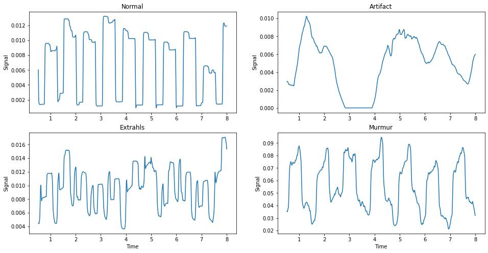

```python
# Rolling window
fig, ax = plt.subplots(2, 2, figsize=(16,8))
ax[0,0].plot(audio_envelope.index, audio_envelope['normal'].rolling(int(sfreq/2)).mean())
ax[0,0].set_ylabel('Signal')
ax[0,0].title.set_text('Normal')
ax[0,1].plot(audio_envelope.index, audio_envelope['artifact'].rolling(int(sfreq/2)).mean())
ax[0,1].set_ylabel('Signal')
ax[0,1].title.set_text('Artifact')
ax[1,0].plot(audio_envelope.index, audio_envelope['extrahls'].rolling(int(sfreq/2)).mean())
ax[1,0].set_ylabel('Signal')
ax[1,0].set_xlabel('Time')
ax[1,0].title.set_text('Extrahls')
ax[1,1].plot(audio_envelope.index, audio_envelope['murmur'].rolling(int(sfreq/2)).mean())
ax[1,1].set_ylabel('Signal')
ax[1,1].set_xlabel('Time')
ax[1,1].title.set_text('Murmur')
plt.show()
```

```python
# Feature engineering on envelope
envelope_mean = np.mean(audio_envelope, axis=0)
envelope_std = np.std(audio_envelope, axis=0)
envelope_max = np.max(audio_envelope, axis=0)

rol_mean = np.mean(audio_envelope.rolling(int(sfreq/2)).mean())
rol_std = np.std(audio_envelope.rolling(int(sfreq/2)).mean())
rol_max = np.max(audio_envelope.rolling(int(sfreq/2)).mean())
```

```python
display(pd.DataFrame([envelope_mean, envelope_std, envelope_max, rol_mean, rol_std, rol_max],
                    index=['mean', 'std', 'max', 'rol_mean', 'rol_std', 'rol_max']))
```

|  | normal | artifact | extrahls | murmur |
| --- | --- | --- | --- | --- |
| mean | 0.007253 | 0.004898 | 0.009546 | 0.055043 |
| std | 0.029361 | 0.003649 | 0.019131 | 0.069378 |
| max | 0.249543 | 0.028115 | 0.113429 | 0.519126 |
| rol_mean | 0.006898 | 0.004859 | 0.009663 | 0.056239 |
| rol_std | 0.004376 | 0.002886 | 0.003056 | 0.019750 |
| rol_max | 0.013228 | 0.010245 | 0.017068 | 0.094531 |

## Tempo features

Tempo is another feature we can extract from waveform data and relates to number of beats per minute.

```python
# Calculate the tempo of the sounds
tempos = []
for col, i_audio in df.items():
    tempos.append(lr.beat.tempo(y=i_audio.values, sr=sfreq, hop_length=2**6, aggregate=None))

# Convert the list to an array so we can manipulate it more easily
tempos = np.array(tempos)

# Calculate statistics of each tempo
tempos_mean = tempos.mean(axis=-1)
tempos_std = tempos.std(axis=-1)
tempos_max = tempos.max(axis=-1)
```

```python
display(pd.DataFrame([tempos_mean, tempos_std, tempos_max],
                    index=['mean', 'std', 'max']))
```

|  | 0 | 1 | 2 | 3 |
| --- | --- | --- | --- | --- |
| mean | 76.511403 | 123.070574 | 112.034087 | 55.473390 |
| std | 1.331489 | 29.969391 | 19.965717 | 0.919956 |
| max | 79.507212 | 156.605114 | 136.899834 | 57.262812 |

## Spectral features

Finally the most important one, spectral analysis over waveforms.  
By applying STFT (short-time Fourier transform) over the waveform, we can extract the spectogram, with frequency content over the time.

```python
# Calculate our STFT
HOP_LENGTH = 2**9
SIZE_WINDOW = 2**12

specs = []
specs_db = []

for audio in audios:
    audio_spec = stft(audio, hop_length=HOP_LENGTH)
    spec_db = amplitude_to_db(np.abs(audio_spec)) # Convert into decibels for visualization
    specs.append(audio_spec)
    specs_db.append(spec_db)
```

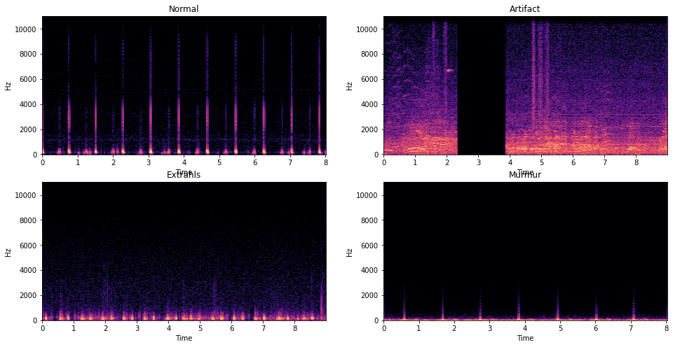

```python
# Visualize
fig, ax = plt.subplots(2, 2, figsize=(16,8))
specshow(specs_db[0], sr=sfreq, x_axis='time',
         y_axis='hz', hop_length=HOP_LENGTH, ax=ax[0,0])
ax[0,0].title.set_text('Normal')

specshow(specs_db[1], sr=sfreq, x_axis='time',
         y_axis='hz', hop_length=HOP_LENGTH, ax=ax[0,1])
ax[0,1].title.set_text('Artifact')

specshow(specs_db[2], sr=sfreq, x_axis='time',
         y_axis='hz', hop_length=HOP_LENGTH, ax=ax[1,0])
ax[1,0].title.set_text('Extrahls')

specshow(specs_db[3], sr=sfreq, x_axis='time',
         y_axis='hz', hop_length=HOP_LENGTH, ax=ax[1,1])
ax[1,1].title.set_text('Murmur')
plt.show()
```

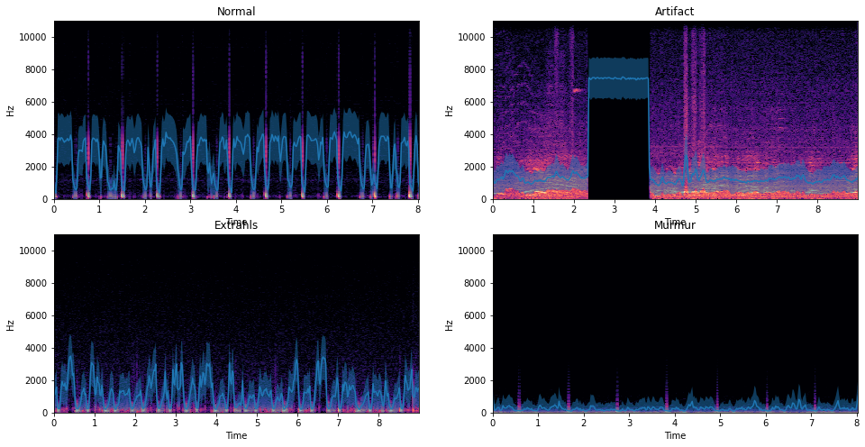

```python
# Calculate the spectral centroid and bandwidth for the spectograms
bandwidths = []
centroids = []
times_spec = []

for i, spec in enumerate(specs):
    bandwidths.append(lr.feature.spectral_bandwidth(S=np.abs(spec))[0])
    centroids.append(lr.feature.spectral_centroid(S=np.abs(spec))[0])
    times_spec.append(np.linspace(0, times[i][-1], len(centroids[i])))

# Display these features on top of the spectogram
fig, ax = plt.subplots(2, 2, figsize=(16,8))
specshow(specs_db[0], sr=sfreq, x_axis='time',
         y_axis='hz', hop_length=HOP_LENGTH, ax=ax[0,0])
ax[0,0].plot(times_spec[0], centroids[0])
ax[0,0].fill_between(times_spec[0], centroids[0]-bandwidths[0]/2, centroids[0]+bandwidths[0]/2, alpha=0.5)
ax[0,0].set(ylim=[0, 11000])
ax[0,0].set(xlim=[0, times[0][-1]])
ax[0,0].title.set_text('Normal')

specshow(specs_db[1], sr=sfreq, x_axis='time',
         y_axis='hz', hop_length=HOP_LENGTH, ax=ax[0,1])
ax[0,1].plot(times_spec[1], centroids[1])
ax[0,1].fill_between(times_spec[1], centroids[1]-bandwidths[1]/2, centroids[1]+bandwidths[1]/2, alpha=0.5)
ax[0,1].set(ylim=[0, 11000])
ax[0,1].set(xlim=[0, times[1][-1]])
ax[0,1].title.set_text('Artifact')

specshow(specs_db[2], sr=sfreq, x_axis='time',
         y_axis='hz', hop_length=HOP_LENGTH, ax=ax[1,0])
ax[1,0].plot(times_spec[2], centroids[2])
ax[1,0].fill_between(times_spec[2], centroids[2]-bandwidths[2]/2, centroids[2]+bandwidths[2]/2, alpha=0.5)
ax[1,0].set(ylim=[0, 11000])
ax[1,0].set(xlim=[0, times[2][-1]])
ax[1,0].title.set_text('Extrahls')

specshow(specs_db[3], sr=sfreq, x_axis='time',
         y_axis='hz', hop_length=HOP_LENGTH, ax=ax[1,1])
ax[1,1].plot(times_spec[3], centroids[3])
ax[1,1].fill_between(times_spec[3], centroids[3]-bandwidths[3]/2, centroids[3]+bandwidths[3]/2, alpha=0.5)
ax[1,1].set(ylim=[0, 11000])
ax[1,1].set(xlim=[0, times[3][-1]])
ax[1,1].title.set_text('Murmur')
plt.show()
```

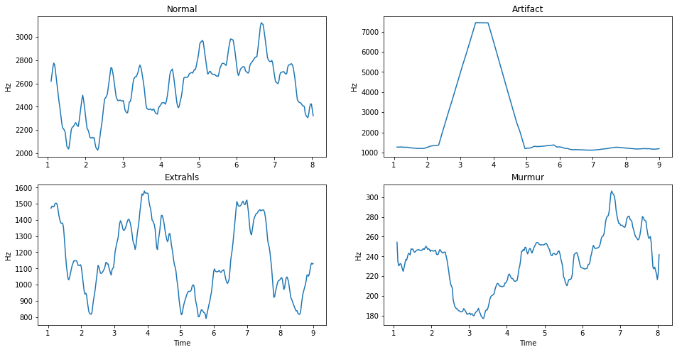

```python
w = 48

# Rolling window of spectral content
fig, ax = plt.subplots(2, 2, figsize=(16,8))
ax[0,0].plot(times_spec[0], pd.DataFrame(centroids[0]).rolling(w).mean())
ax[0,0].set_ylabel('Hz')
ax[0,0].title.set_text('Normal')
ax[0,1].plot(times_spec[1], pd.DataFrame(centroids[1]).rolling(w).mean())
ax[0,1].set_ylabel('Hz')
ax[0,1].title.set_text('Artifact')
ax[1,0].plot(times_spec[2], pd.DataFrame(centroids[2]).rolling(w).mean())
ax[1,0].set_ylabel('Hz')
ax[1,0].set_xlabel('Time')
ax[1,0].title.set_text('Extrahls')
ax[1,1].plot(times_spec[3], pd.DataFrame(centroids[3]).rolling(w).mean())
ax[1,1].set_ylabel('Hz')
ax[1,1].set_xlabel('Time')
ax[1,1].title.set_text('Murmur')
plt.show()
```

# Classification model

## Feature extraction of training set

For our classification model, we will develop a simple binary classifier. We will use files of normal and murmur labels only. We will apply database (B) as training set and database (A) as test set, to evaluate our classifier. As classification features, we will apply all those presented previously, over the envelope, tempo and frequency domains.

```python
files = glob('archive/set_b/*.wav')
```

```python
df = b_df[b_df['label'].isin(['normal','murmur'])]
df
```

|  | dataset | fname | label | sublabel |
| --- | --- | --- | --- | --- |
| 46 | b | set_b/Btraining_murmur_112_1306243000964_A.wav | murmur | NaN |
| 47 | b | set_b/Btraining_murmur_112_1306243000964_B.wav | murmur | NaN |
| 48 | b | set_b/Btraining_murmur_112_1306243000964_D.wav | murmur | NaN |
| 49 | b | set_b/Btraining_murmur_116_1306258689913_A.wav | murmur | NaN |
| 50 | b | set_b/Btraining_murmur_116_1306258689913_C.wav | murmur | NaN |
| ... | ... | ... | ... | ... |
| 651 | b | set_b/Btraining_normal_Btraining_noisynormal_2... | normal | noisynormal |
| 652 | b | set_b/Btraining_normal_Btraining_noisynormal_2... | normal | noisynormal |
| 653 | b | set_b/Btraining_normal_Btraining_noisynormal_2... | normal | noisynormal |
| 654 | b | set_b/Btraining_normal_Btraining_noisynormal_2... | normal | noisynormal |
| 655 | b | set_b/Btraining_normal_Btraining_noisynormal_2... | normal | noisynormal |

415 rows × 4 columns

```python
for file in files:
    try:
        file_number = re.search('([0-9]+.*)', file)[0]
        ind = df[df['fname'].str.contains(file_number)].index[0]
        df.loc[ind, 'file'] = file
    except:
        pass

df = df[~df['file'].isna()]
df.set_index('file', drop=True, inplace=True)
```

```python
df
```

| file | dataset | fname | label | sublabel |
| --- | --- | --- | --- | --- |
| archive/set_b/murmur__112_1306243000964_A.wav | b | set_b/Btraining_murmur_112_1306243000964_A.wav | murmur | NaN |
| archive/set_b/murmur__112_1306243000964_B.wav | b | set_b/Btraining_murmur_112_1306243000964_B.wav | murmur | NaN |
| archive/set_b/murmur__112_1306243000964_D.wav | b | set_b/Btraining_murmur_112_1306243000964_D.wav | murmur | NaN |
| archive/set_b/murmur__116_1306258689913_A.wav | b | set_b/Btraining_murmur_116_1306258689913_A.wav | murmur | NaN |
| archive/set_b/murmur__116_1306258689913_C.wav | b | set_b/Btraining_murmur_116_1306258689913_C.wav | murmur | NaN |
| ... | ... | ... | ... | ... |
| archive/set_b/normal_noisynormal_284_1311168471850_A.wav | b | set_b/Btraining_normal_Btraining_noisynormal_2... | normal | noisynormal |
| archive/set_b/normal_noisynormal_284_1311168471850_B.wav | b | set_b/Btraining_normal_Btraining_noisynormal_2... | normal | noisynormal |
| archive/set_b/normal_noisynormal_285_1311169246969_C.wav | b | set_b/Btraining_normal_Btraining_noisynormal_2... | normal | noisynormal |
| archive/set_b/normal_noisynormal_296_1311682952647_C.wav | b | set_b/Btraining_normal_Btraining_noisynormal_2... | normal | noisynormal |
| archive/set_b/normal_noisynormal_296_1311682952647_D.wav | b | set_b/Btraining_normal_Btraining_noisynormal_2... | normal | noisynormal |

412 rows × 4 columns

```python
window_size = 500
HOP_LENGTH = 2**9
SIZE_WINDOW = 2**12
i = 0

features = pd.DataFrame(columns=['envelope_mean','envelope_std','envelope_max',
                                 'rol_env_mean','rol_env_std','rol_env_max',
                                 'tempo_mean','tempo_std','tempo_max',
                                 'band_mean','cent_mean',
                                 'rol_spec_mean','rol_spec_std','rol_spec_max'])

for file, row in df.iterrows():
    i += 1
    if i%50 == 0:
        print(f'{file} : {i}/412')

    # Reading audio file
    audio, sfreq = lr.load(file)

    # Creating time array
    indices = np.arange(0, len(audio))
    time = indices/sfreq

    # Envelope features
    df_audio = pd.DataFrame(audio)
    audio_envelope = df_audio.apply(np.abs).rolling(window_size).mean()
    envelope_mean = np.mean(audio_envelope, axis=0)[0]
    envelope_std = np.std(audio_envelope, axis=0)[0]
    envelope_max = np.max(audio_envelope, axis=0)[0]
    features.loc[file, 'envelope_mean'] = envelope_mean
    features.loc[file, 'envelope_std'] = envelope_std
    features.loc[file, 'envelope_max'] = envelope_max

    # Rolling envelope features
    rol_env_mean = np.mean(audio_envelope.rolling(int(sfreq/2)).mean())[0]
    rol_env_std = np.std(audio_envelope.rolling(int(sfreq/2)).mean())[0]
    rol_env_max = np.max(audio_envelope.rolling(int(sfreq/2)).mean())[0]
    features.loc[file, 'rol_env_mean'] = rol_env_mean
    features.loc[file, 'rol_env_std'] = rol_env_std
    features.loc[file, 'rol_env_max'] = rol_env_max

    # Tempo features
    tempo = lr.beat.tempo(y=audio, sr=sfreq, hop_length=2**6, aggregate=None)
    tempo_mean = tempo.mean(axis=-1)
    tempo_std = tempo.std(axis=-1)
    tempo_max = tempo.max(axis=-1)
    features.loc[file, 'tempo_mean'] = tempo_mean
    features.loc[file, 'tempo_std'] = tempo_std
    features.loc[file, 'tempo_max'] = tempo_max

    # Spectral features
    spec = stft(audio, hop_length=HOP_LENGTH)
    centroid = lr.feature.spectral_centroid(S=np.abs(spec))
    band_mean = np.mean(lr.feature.spectral_bandwidth(S=np.abs(spec)))
    cent_mean = np.mean(centroid)
    features.loc[file, 'band_mean'] = band_mean
    features.loc[file, 'cent_mean'] = cent_mean

    # Rolling spectral features
    rol_spec_mean = np.mean(pd.DataFrame(centroid[0]).rolling(48).mean())[0]
    rol_spec_std = np.std(pd.DataFrame(centroid[0]).rolling(48).mean())[0]
    rol_spec_max = np.max(pd.DataFrame(centroid[0]).rolling(48).mean())[0]
    features.loc[file, 'rol_spec_mean'] = rol_spec_mean
    features.loc[file, 'rol_spec_std'] = rol_spec_std
    features.loc[file, 'rol_spec_max'] = rol_spec_max

print(f'{file} : {i}/412')
```

```
archive/set_b/murmur__244_1309198148498_B.wav : 50/412
archive/set_b/normal__137_1306764999211_C.wav : 100/412
archive/set_b/normal__170_1307970562729_A.wav : 150/412
archive/set_b/normal__209_1308162216750_A.wav : 200/412
archive/set_b/normal__282_1311166081161_C.wav : 250/412
archive/set_b/normal_noisynormal_107_1305654946865_A.wav : 300/412
archive/set_b/normal_noisynormal_137_1306764999211_D1.wav : 350/412
archive/set_b/normal_noisynormal_264_1309356143724_C.wav : 400/412
archive/set_b/normal_noisynormal_296_1311682952647_D.wav : 412/412
```

```python
features
```

| Unnamed: 0 | envelope_mean | envelope_std | envelope_max | rol_env_mean | rol_env_std | rol_env_max | tempo_mean | tempo_std | tempo_max | band_mean | cent_mean | rol_spec_mean | rol_spec_std | rol_spec_max |
| --- | --- | --- | --- | --- | --- | --- | --- | --- | --- | --- | --- | --- | --- | --- |
| archive/set_b/murmur__112_1306243000964_A.wav | 0.029616 | 0.039656 | 0.256565 | 0.029443 | 0.009835 | 0.052083 | 122.563272 | 3.171611 | 142.564655 | 388.663388 | 307.757889 | 305.204159 | 18.299142 | 340.806170 |
| archive/set_b/murmur__112_1306243000964_B.wav | 0.080671 | 0.117259 | 0.751429 | 0.081459 | 0.023949 | 0.148503 | 142.623971 | 38.528759 | 196.875000 | 307.096908 | 246.360413 | 246.321898 | 39.731223 | 334.974950 |
| archive/set_b/murmur__112_1306243000964_D.wav | 0.039154 | 0.065133 | 0.495011 | 0.039050 | 0.014602 | 0.073650 | 127.124808 | 26.138088 | 186.233108 | 351.627674 | 303.114160 | 303.192225 | 36.031353 | 385.726461 |
| archive/set_b/murmur__116_1306258689913_A.wav | 0.040288 | 0.035095 | 0.269973 | 0.040634 | 0.008101 | 0.058151 | 112.359995 | 28.192894 | 150.889599 | 352.644700 | 283.358025 | 277.767161 | 12.194930 | 307.199390 |
| archive/set_b/murmur__116_1306258689913_C.wav | 0.016960 | 0.014725 | 0.125012 | 0.016975 | 0.004363 | 0.026639 | 129.135469 | 14.767350 | 154.267724 | 427.153801 | 377.463748 | 377.961077 | 29.499340 | 456.322541 |
| ... | ... | ... | ... | ... | ... | ... | ... | ... | ... | ... | ... | ... | ... | ... |
| archive/set_b/normal_noisynormal_284_1311168471850_A.wav | 0.036412 | 0.042268 | 0.228297 | 0.036477 | 0.006010 | 0.051108 | 121.177779 | 23.834819 | 165.375000 | 354.665334 | 322.932842 | 322.194223 | 36.420620 | 437.845739 |
| archive/set_b/normal_noisynormal_284_1311168471850_B.wav | 0.039781 | 0.051964 | 0.364323 | 0.039622 | 0.006845 | 0.054320 | 99.646657 | 4.939613 | 126.821319 | 384.058825 | 389.328554 | 388.813428 | 22.038180 | 445.606226 |
| archive/set_b/normal_noisynormal_285_1311169246969_C.wav | 0.018664 | 0.025828 | 0.146681 | 0.018568 | 0.004709 | 0.030776 | 115.262789 | 1.411450 | 118.803879 | 491.346528 | 424.323041 | 429.251745 | 67.338075 | 571.937269 |
| archive/set_b/normal_noisynormal_296_1311682952647_C.wav | 0.048895 | 0.052445 | 0.436355 | 0.048987 | 0.012326 | 0.096403 | 127.684934 | 9.144677 | 136.899834 | 395.547843 | 377.467977 | 377.268749 | 27.595868 | 463.881173 |
| archive/set_b/normal_noisynormal_296_1311682952647_D.wav | 0.051436 | 0.060907 | 0.288201 | 0.051921 | 0.014091 | 0.113271 | 132.010060 | 1.342449 | 133.366935 | 355.760134 | 333.697390 | 330.987210 | 20.294923 | 386.362722 |

412 rows × 14 columns

```python
files_na = ['archive/set_b/murmur__171_1307971016233_E.wav',
            'archive/set_b/normal__286_1311170606028_A1.wav',
            'archive/set_b/normal__296_1311682952647_A1.wav']

features = features[~features.index.isin(files_na)]
df = df[~df.index.isin(files_na)]
```

```python
X_train = features
y_train = df['label']
y_train[y_train == 'murmur'] = 1
y_train[y_train == 'normal'] = 0
y_train = y_train.astype('int')
```

## Feature extraction of test set

```python
df2 = a_df[a_df['label'].isin(['normal','murmur'])]
df2.set_index('fname', inplace=True)
df2
```

| fname | label |
| --- | --- |
| archive/set_a/murmur__201101051104.wav | murmur |
| archive/set_a/murmur__201101051108.wav | murmur |
| archive/set_a/murmur__201101051114.wav | murmur |
| archive/set_a/murmur__201101180902.wav | murmur |
| archive/set_a/murmur__201102051443.wav | murmur |
| ... | ... |
| archive/set_a/normal__201106221450.wav | normal |
| archive/set_a/normal__201108011112.wav | normal |
| archive/set_a/normal__201108011114.wav | normal |
| archive/set_a/normal__201108011115.wav | normal |
| archive/set_a/normal__201108011118.wav | normal |

65 rows × 1 columns

```python
window_size = 500
HOP_LENGTH = 2**9
SIZE_WINDOW = 2**12
i = 0

features2 = pd.DataFrame(columns=['envelope_mean','envelope_std','envelope_max',
                                 'rol_env_mean','rol_env_std','rol_env_max',
                                 'tempo_mean','tempo_std','tempo_max',
                                 'band_mean','cent_mean',
                                 'rol_spec_mean','rol_spec_std','rol_spec_max'])

for file, row in df2.iterrows():
    i += 1
    if i%10 == 0:
        print(f'{file} : {i}/65')

    # Reading audio file
    audio, sfreq = lr.load(file)

    # Creating time array
    indices = np.arange(0, len(audio))
    time = indices/sfreq

    # Envelope features
    df_audio = pd.DataFrame(audio)
    audio_envelope = df_audio.apply(np.abs).rolling(window_size).mean()
    envelope_mean = np.mean(audio_envelope, axis=0)[0]
    envelope_std = np.std(audio_envelope, axis=0)[0]
    envelope_max = np.max(audio_envelope, axis=0)[0]
    features2.loc[file, 'envelope_mean'] = envelope_mean
    features2.loc[file, 'envelope_std'] = envelope_std
    features2.loc[file, 'envelope_max'] = envelope_max

    # Rolling envelope features
    rol_env_mean = np.mean(audio_envelope.rolling(int(sfreq/2)).mean())[0]
    rol_env_std = np.std(audio_envelope.rolling(int(sfreq/2)).mean())[0]
    rol_env_max = np.max(audio_envelope.rolling(int(sfreq/2)).mean())[0]
    features2.loc[file, 'rol_env_mean'] = rol_env_mean
    features2.loc[file, 'rol_env_std'] = rol_env_std
    features2.loc[file, 'rol_env_max'] = rol_env_max

    # Tempo features
    tempo = lr.beat.tempo(y=audio, sr=sfreq, hop_length=2**6, aggregate=None)
    tempo_mean = tempo.mean(axis=-1)
    tempo_std = tempo.std(axis=-1)
    tempo_max = tempo.max(axis=-1)
    features2.loc[file, 'tempo_mean'] = tempo_mean
    features2.loc[file, 'tempo_std'] = tempo_std
    features2.loc[file, 'tempo_max'] = tempo_max

    # Spectral features
    spec = stft(audio, hop_length=HOP_LENGTH)
    centroid = lr.feature.spectral_centroid(S=np.abs(spec))
    band_mean = np.mean(lr.feature.spectral_bandwidth(S=np.abs(spec)))
    cent_mean = np.mean(centroid)
    features2.loc[file, 'band_mean'] = band_mean
    features2.loc[file, 'cent_mean'] = cent_mean

    # Rolling spectral features
    rol_spec_mean = np.mean(pd.DataFrame(centroid[0]).rolling(48).mean())[0]
    rol_spec_std = np.std(pd.DataFrame(centroid[0]).rolling(48).mean())[0]
    rol_spec_max = np.max(pd.DataFrame(centroid[0]).rolling(48).mean())[0]
    features2.loc[file, 'rol_spec_mean'] = rol_spec_mean
    features2.loc[file, 'rol_spec_std'] = rol_spec_std
    features2.loc[file, 'rol_spec_max'] = rol_spec_max

print(f'{file} : {i}/65')
```

```
archive/set_a/murmur__201104291843.wav : 10/65
archive/set_a/murmur__201108222235.wav : 20/65
archive/set_a/murmur__201108222252.wav : 30/65
archive/set_a/normal__201102260502.wav : 40/65
archive/set_a/normal__201104122156.wav : 50/65
archive/set_a/normal__201106221418.wav : 60/65
archive/set_a/normal__201108011118.wav : 65/65
```

```python
features2
```

| Unnamed: 0 | envelope_mean | envelope_std | envelope_max | rol_env_mean | rol_env_std | rol_env_max | tempo_mean | tempo_std | tempo_max | band_mean | cent_mean | rol_spec_mean | rol_spec_std | rol_spec_max |
| --- | --- | --- | --- | --- | --- | --- | --- | --- | --- | --- | --- | --- | --- | --- |
| archive/set_a/murmur__201101051104.wav | 0.006933 | 0.010810 | 0.058625 | 0.006836 | 0.002482 | 0.011689 | 118.779842 | 33.241787 | 161.499023 | 2073.421953 | 1299.849966 | 1299.922538 | 116.808762 | 1608.506848 |
| archive/set_a/murmur__201101051108.wav | 0.004211 | 0.010139 | 0.053660 | 0.004147 | 0.002112 | 0.008425 | 130.200238 | 0.659588 | 131.667994 | 2339.223848 | 2601.622592 | 2613.825375 | 196.012075 | 3001.610146 |
| archive/set_a/murmur__201101051114.wav | 0.035074 | 0.037657 | 0.312929 | 0.034892 | 0.010351 | 0.057709 | 121.143638 | 11.161158 | 147.656250 | 1925.549710 | 966.560701 | 956.785975 | 43.127071 | 1045.849637 |
| archive/set_a/murmur__201101180902.wav | 0.054968 | 0.069239 | 0.519126 | 0.056127 | 0.019774 | 0.094531 | 55.481259 | 0.925666 | 57.262812 | 997.225121 | 242.264160 | 235.430952 | 28.805209 | 306.117101 |
| archive/set_a/murmur__201102051443.wav | 0.017667 | 0.019476 | 0.163166 | 0.018079 | 0.003972 | 0.028357 | 120.750035 | 10.057531 | 145.576585 | 1901.542487 | 1102.638283 | 1098.912886 | 73.235945 | 1246.264629 |
| ... | ... | ... | ... | ... | ... | ... | ... | ... | ... | ... | ... | ... | ... | ... |
| archive/set_a/normal__201106221450.wav | 0.016585 | 0.030484 | 0.195280 | 0.016409 | 0.004014 | 0.026297 | 115.956375 | 13.170953 | 179.755435 | 1469.167352 | 668.009789 | 667.748721 | 50.712077 | 812.783618 |
| archive/set_a/normal__201108011112.wav | 0.028129 | 0.055734 | 0.328286 | 0.028913 | 0.010081 | 0.044716 | 123.866022 | 0.233707 | 124.529367 | 556.484492 | 164.342986 | 157.089317 | 9.853297 | 192.038193 |
| archive/set_a/normal__201108011114.wav | 0.020082 | 0.039920 | 0.261232 | 0.020800 | 0.010132 | 0.035562 | 128.255823 | 3.934739 | 148.718525 | 602.256006 | 179.089155 | 171.955421 | 7.062927 | 199.609915 |
| archive/set_a/normal__201108011115.wav | 0.025655 | 0.046168 | 0.264670 | 0.025057 | 0.008818 | 0.037298 | 121.357722 | 0.336778 | 121.599265 | 553.202637 | 156.667061 | 158.183435 | 8.488763 | 179.160240 |
| archive/set_a/normal__201108011118.wav | 0.038313 | 0.059735 | 0.270689 | 0.038239 | 0.008150 | 0.049307 | 90.329693 | 0.141479 | 90.666118 | 488.965049 | 137.959979 | 133.220252 | 5.805155 | 152.869878 |

65 rows × 14 columns

```python
file_na = ['archive/set_a/murmur__201104021355.wav']

features2 = features2[~features2.index.isin(file_na)]
df2 = df2[~df2.index.isin(file_na)]
```

```python
X_test = features2
y_test = df2['label']
y_test[y_test == 'murmur'] = 1
y_test[y_test == 'normal'] = 0
y_test = y_test.astype('int')
```

# Classifier ROC (Receiver Operating Characteristic Curve)

For our problem we have a total of 14 features extracted from the waveform files. We will apply a Logistic Regression, since this is a binary classification problem and analyze the model with a dummy classifier, by applying the ROC curve.

```python
# Fitting the model
model = LogisticRegression(max_iter=1000)
model.fit(X_train, y_train)
```

```
LogisticRegression(max_iter=1000)
```

```python
# Probabilities
# generate a no skill prediction (majority class)
ns_probs = [0 for _ in range(len(y_test))]

# predict probabilities
lr_probs = model.predict_proba(X_test)
# keep probabilities for the positive outcome only
lr_probs = lr_probs[:, 1]
```

```python
# auc
# calculate scores
ns_auc = roc_auc_score(y_test, ns_probs)
lr_auc = roc_auc_score(y_test, lr_probs)

# summarize scores
print('No Skill: ROC AUC=%.3f' % (ns_auc))
print('Logistic: ROC AUC=%.3f' % (lr_auc))
```

```
No Skill: ROC AUC=0.500
Logistic: ROC AUC=0.855
```

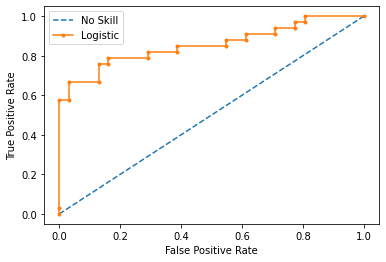

```python
# calculate roc curves
ns_fpr, ns_tpr, _ = roc_curve(y_test, ns_probs)
lr_fpr, lr_tpr, _ = roc_curve(y_test, lr_probs)

# plot the roc curve for the model
plt.plot(ns_fpr, ns_tpr, linestyle='--', label='No Skill')
plt.plot(lr_fpr, lr_tpr, marker='.', label='Logistic')

# axis labels
plt.xlabel('False Positive Rate')
plt.ylabel('True Positive Rate')
# show the legend
plt.legend()
# show the plot
plt.show()
```

```python
# Predictions
model = LogisticRegression(max_iter=1000)
model.fit(X_train, y_train)

probs = model.predict_proba(X_test)
probs = probs[:,1]
predictions = probs >= median(np.sort(probs))
percent_score = accuracy_score(y_test, predictions)
recall = recall_score(y_test, predictions)
```

```python
print(percent_score)
print(recall)
```

```
0.796875
0.7878787878787878
```

As we can see, our model has an accuracy of 0.797. It also has a recall of 0.788, which in this case is more important than accuracy, since we need to detect abnormalities, in case of their real occurrence.

This was just a small simple study case of time series waveforms and we could still improve more the feature engineering and model performance, by removing noise, normalizing data and extracting its variation, instead of using the absolute value.